# Chicago - Chicago - Red Light Violation

Sebastiano Quintavalle

2024-01-12

# 1. Data preparation and setup

## Environment setup

The initial operations involve **clearing the existing environment** to prevent potential conflicts and setting the **system language**.

```r
Sys.setlocale("LC_TIME", "en_US.UTF-8")
```

```
## [1] "en_US.UTF-8"
```

```r
rm(list=ls())
dev.off()
```

Loading the necessary **packages** for the project.

```r
library(forecast)
```

Importing **custom variables** and **functions** from local files.

```r
source("./src/smoothing.R")
source("./src/globals.R")
source("./src/utils.R")
```

## Data preparation

### Reading file

Reading the `violations.csv` file, containing preprocessed **daily traffic light violation** data from the [Chicago Data Portal](https://data.cityofchicago.org/Transportation/Red-Light-Camera-Violations/spqx-js37/data_preview).

```r
# Reading the file
violations.regions.df <- read.csv(file=violation_file)

# Casting Regions as factors
violations.regions.df$Region = as.factor(violations.regions.df$Region)

# Converting Date column to DateType
violations.regions.df$Date <- as.Date(
  x      = as.character(violations.regions.df$Date),
  format = "%m/%d/%Y"
)

head(violations.regions.df)
```

```
##         Region       Date Violations
## 1      Central 2015-01-01         24
## 2 FarSouthEast 2015-01-01         60
## 3         West 2015-01-01        288
## 4 FarSouthWest 2015-01-01         59
## 5        North 2015-01-01        186
## 6        South 2015-01-01         80
```

```r
summary(violations.regions.df)
```

```
##           Region          Date              Violations
##  Central     :2922   Min.   :2015-01-01   Min.   :  1.0
##  FarNorth    :2922   1st Qu.:2016-12-31   1st Qu.: 94.0
##  FarSouthEast:2922   Median :2018-12-31   Median :138.0
##  FarSouthWest:2922   Mean   :2018-12-31   Mean   :159.4
##  North       :2922   3rd Qu.:2020-12-31   3rd Qu.:205.0
##  NorthWest   :2922   Max.   :2022-12-31   Max.   :807.0
##  (Other)     :8766
```

### Aggregating by areas

The dataset encompasses observations for **nine distinct regions** within Chicago. To streamline the analysis, which could become cumbersome when examining each of the nine regions individually, a **subsequent aggregation** is conducted, categorizing the city into **three primary areas**:

- *North*: FarNorth, NorthWest, North.
- *Center*: Central, West, SouthWest, South.
- *South*: FarSouthWest, FarSouthEast.

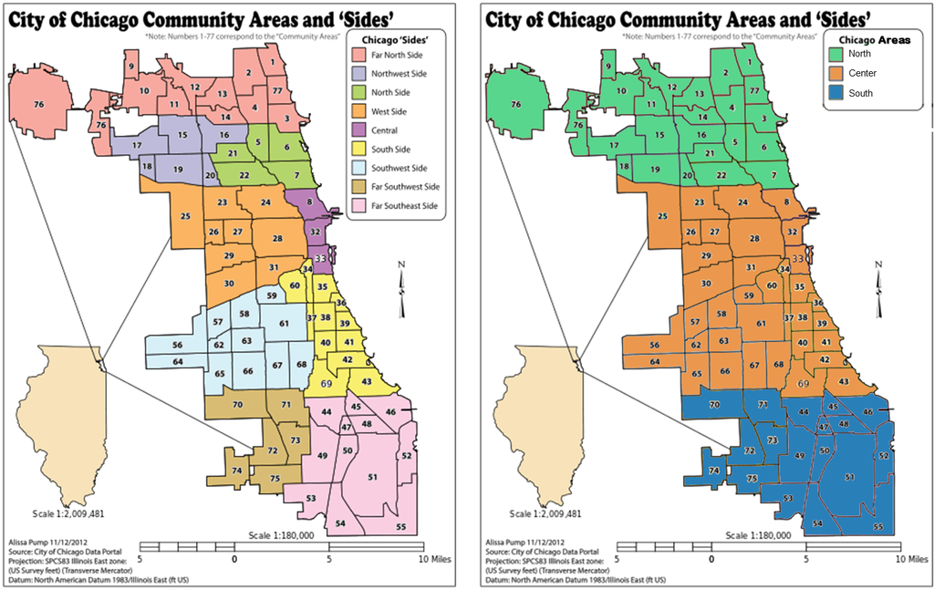

```r
# Names of the nine regions
levels(violations.regions.df$Region)
```

```
## [1] "Central"      "FarNorth"     "FarSouthEast" "FarSouthWest" "North"
## [6] "NorthWest"    "South"        "SouthWest"    "West"
```

```r
# Area of each region
names.regions
```

```
## $North
## [1] "FarNorth"  "NorthWest" "North"
##
## $Center
## [1] "Central"   "West"      "SouthWest" "South"
##
## $South
## [1] "FarSouthWest" "FarSouthEast"
```

```r
# Assigning each Region to the specific Area
violations.regions.df$Area <-
  ifelse(violations.regions.df$Region %in% names.regions$North,  'North',
  ifelse(violations.regions.df$Region %in% names.regions$Center, 'Center',
  ifelse(violations.regions.df$Region %in% names.regions$South,  'South',  NA)))

violations.regions.df$Area = as.factor(violations.regions.df$Area)

# Areas
levels(violations.regions.df$Area)
```

```
## [1] "Center" "North"  "South"
```

```r
names.area
```

```
## [1] "North"  "Center" "South"
```

```r
# Aggregating violations by areas
violations.areas.df = aggregate(
  Violations ~ Area + Date,
  data = violations.regions.df,
  sum
)

head(violations.areas.df)
```

```
##     Area       Date Violations
## 1 Center 2015-01-01        510
## 2  North 2015-01-01        398
## 3  South 2015-01-01        119
## 4 Center 2015-01-02        436
## 5  North 2015-01-02        317
## 6  South 2015-01-02        128
```

```r
summary(violations.areas.df)
```

```
##      Area           Date              Violations
##  Center:2922   Min.   :2015-01-01   Min.   :  39.0
##  North :2922   1st Qu.:2016-12-31   1st Qu.: 259.0
##  South :2922   Median :2018-12-31   Median : 471.0
##                Mean   :2018-12-31   Mean   : 478.2
##                3rd Qu.:2020-12-31   3rd Qu.: 638.0
##                Max.   :2022-12-31   Max.   :1641.0
```

### Splitting dataset

We utilize the labels associated with each region and area to **partition the dataset into a list** of datasets, with each one linked to a specific region or area.

```r
# List of regions
region.df <- split(
  violations.regions.df,
  violations.regions.df$Region
)

names(region.df)
```

```
## [1] "Central"      "FarNorth"     "FarSouthEast" "FarSouthWest" "North"
## [6] "NorthWest"    "South"        "SouthWest"    "West"
```

```r
# List of areas
area.df <- split(
  violations.areas.df,
  violations.areas.df$Area
)

names(area.df)
```

```
## [1] "Center" "North"  "South"
```

## Creating time series

We employ custom functions to transform the dataset into both **daily** and **monthly formats**. The monthly format involves aggregating the total number of violations within each month, revealing essential insights for seasonality analysis.

```r
# To daily
region.ts.daily <- lapply(
  region.df,
  daily_df_to_daily_ts
)

area.ts.daily <- lapply(
  area.df,
  daily_df_to_daily_ts
)

# To monthly
region.ds.monthly <- lapply(
  region.df,
  daily_df_to_monthly_ts
)

area.ts.monthly <- lapply(
  area.df,
  daily_df_to_monthly_ts
)
```

## Visualization

### Regions daily violaitions

We plot the daily violations of the nine regions.

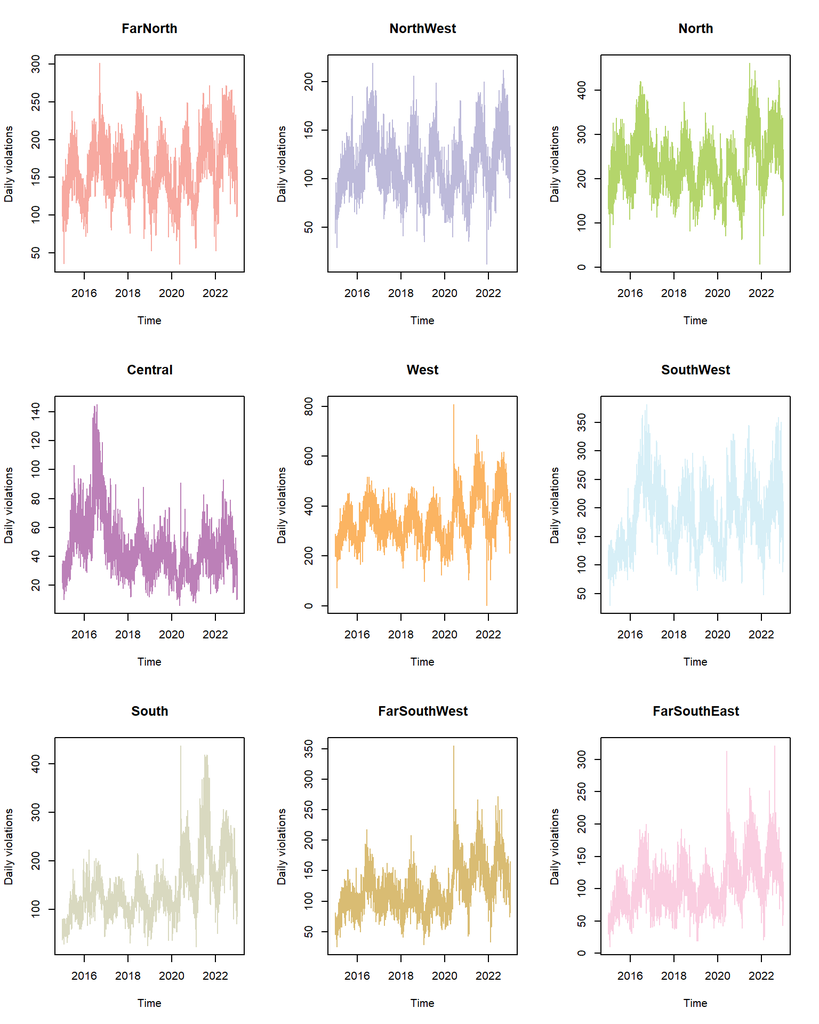

```r
par(mfrow = c(length(region.ts.daily) %/% 3, 3))

for (region_name in unlist(names.regions)) {

  daily        <- region.ts.daily[[region_name]]
  region_color <- region.colors[[region_name]]

  plot(
    daily,
    main=region_name,
    col=region_color,
    ylab="Daily violations"
  )
}
```

```r
par(mfrow = c(1, 1))
```

### Area daily violaitions

We plot the daily violations of the three areas.

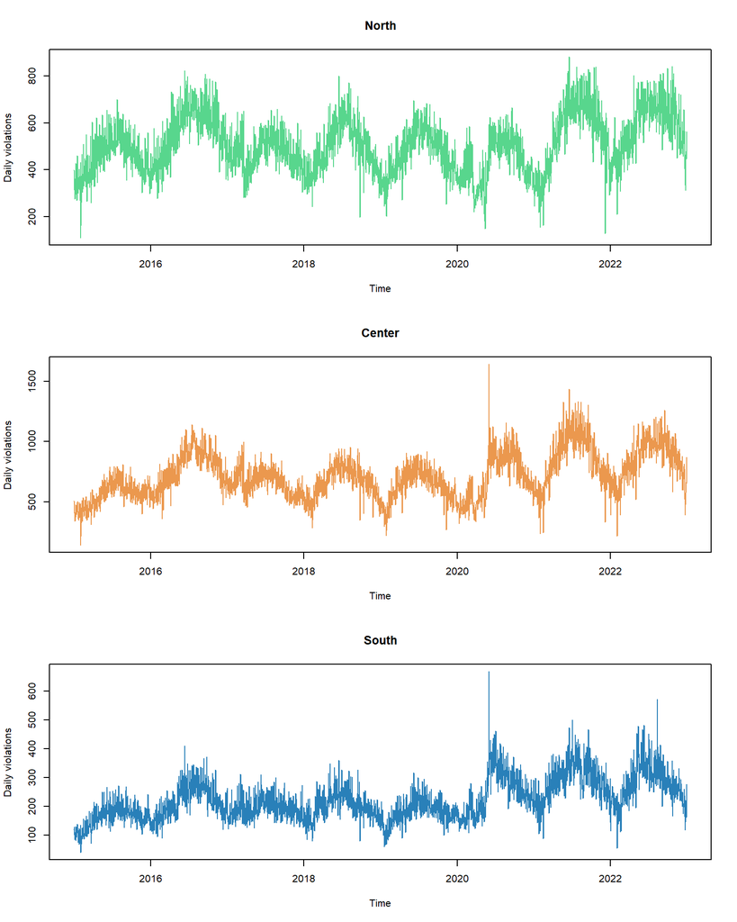

```r
par(mfrow = c(length(names.area), 1))

for (area_name in names.area) {

  daily      <- area.ts.daily[[area_name]]
  area_color <- area.colors[[area_name]]

  plot(
    daily,
    main=area_name,
    col=area_color,
    ylab="Daily violations"
  )
}
```

```r
par(mfrow = c(1, 1))
```

We plot them in the same graph to compare magnitudes.

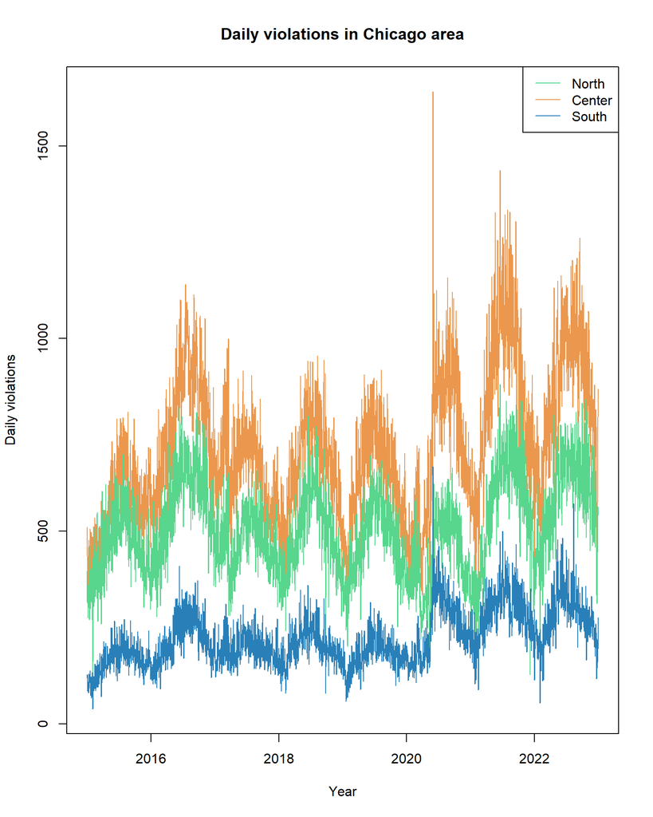

```r
plot_multiple_time_series(
  ts_list=area.ts.daily,
  colors=area.colors,
  legends=names.area,
  main="Daily violations in Chicago area",
  ylab="Daily violations"
)
```

### Anomaly date

The plot exhibits **evidence of an outlier point**, contributing to a peak in violations in the Center and South areas, as well as a significant drop in the North area.

```r
get_observation_over_threshold(
  ts=area.ts.daily$Center,
  threshold = 1500
)
```

```
## [1] "2020-05-30"
```

The data corresponds to `May 30, 2020`, a date notable for the Black Lives Matter protest, during which the city was partially locked down due to a series of riots, seev more [here](https://en.wikipedia.org/wiki/George_Floyd_protests_in_Chicago).

# 2. Trend and Seasonality decomposition

### Extracting trend with smoothing and Low-pass filters

We are interested in understanding if data is regulated by a a generic trend, for this reason we apply examples of low-pass filters to revels such structure.

#### Simple moving average filter

The filter computes an arithmetic average within a time window $p$.

$$\hat{f}_t = \frac{1}{2p + 1} \sum_{i=-p}^p y_{t+i}$$

The value of $p$ plays a significant role in determining the importance of smoothing.

```r
# Using different values of p
p        <- c(         60,           120,          183)
p.colors <- c('lawngreen', 'deepskyblue', 'chocolate1')

par(mfrow = c(length(area.ts.daily), 1))

for (area_name in names.area) {

  daily <- area.ts.daily[[area_name]]

  simple_moving_average_varying_p(
    ts=daily,
    p=p,
    p.color=p.colors,
    main=paste(area_name, "- Simple Moving Average filter"),
    ylab="Daily violations"
  )

}
```

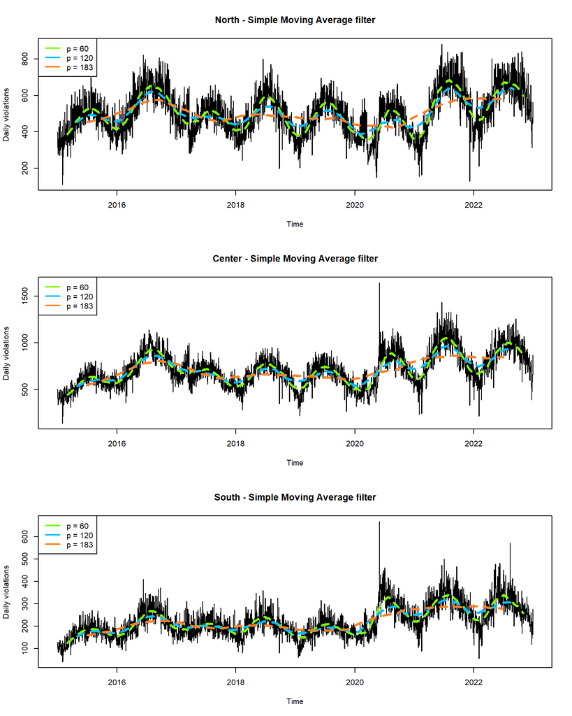

```r
par(mfrow=c(1,1))
```

#### Binomial filter

The filter computes an weighted average within a time window $p$ using Newton binomial coefficients as weights.

$$\hat{f}_t = \frac{1}{2^{p-1}} \sum_{i=0}^p {p \choose j} y_{t-\lceil
p/2\rceil + j}$$

```r
# Uncomment to set value and colors different from previous ones
# p        <- c(         60,           120,          183)
# p.colors <- c('lawngreen', 'deepskyblue', 'chocolate1')

par(mfrow = c(length(area.ts.daily), 1))

for (area_name in names.area) {

  daily <- area.ts.daily[[area_name]]

  binomial_varying_p(
    ts=daily,
    p=p,
    p.color=p.colors,
    main=paste(area_name, "- Binomial filter"),
    ylab="Daily violations"
  )

}
```

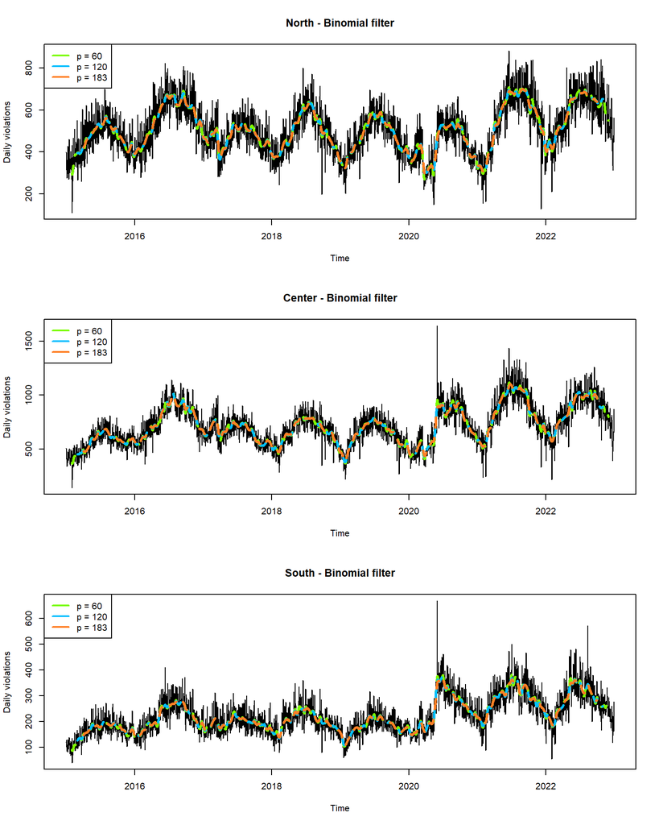

```r
par(mfrow=c(1,1))
```

#### Spencer

Spencer’s $15$-point filter is a symmetric moving average invariant to linear, quadratic and cubic polynomials.

$$\begin{aligned}
i:\quad &0& &\pm 1& &\pm 2& &\pm 3&
&\pm 4& &\pm 5& &\pm 6& &\pm 7& \\
a_i^*:\quad &74& &\pm 67& &\pm 46& &\pm
21& &\pm 3& &\pm -5& &\pm -6& &\pm
-3&
\end{aligned}$$

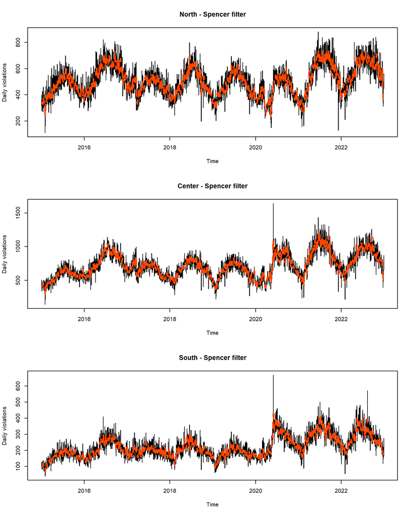

```r
par(mfrow = c(length(area.ts.daily), 1))

for (area_name in names.area) {

  daily <- area.ts.daily[[area_name]]

  plot(
    daily,
    main=paste(area_name, "- Spencer filter"),
    ylab="Daily violations"
  )

  spencer.trend = spencer(ts=daily)

  lines(
    spencer.trend,
    lty='dashed', lwd=3,
    col='orangered'
  )

}
```

```r
par(mfrow=c(1,1))
```

Let’s use monthly

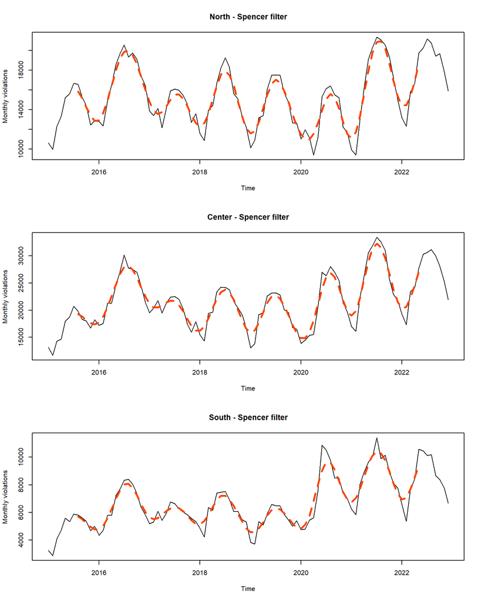

```r
par(mfrow = c(length(area.ts.monthly), 1))

for (area_name in names.area) {

  monthly <- area.ts.monthly[[area_name]]

  plot(
    monthly,
    main=paste(area_name, "- Spencer filter"),
    ylab="Monthly violations"
  )

  spencer.trend = spencer(ts=monthly)

  lines(
    spencer.trend,
    lty='dashed', lwd=3,
    col='orangered'
  )

}
```

```r
par(mfrow=c(1,1))
```

#### Deseasoning filter

We can highlight trend by removing seasonality effect, this can be achieved with a filter that average among two consecutive time windows considering a period $p$.

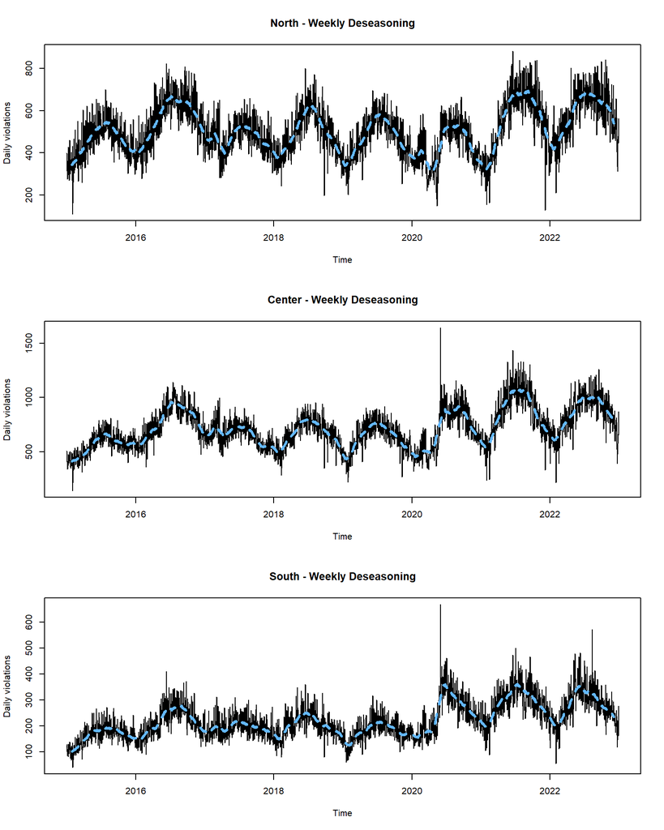

```r
par(mfrow = c(length(area.ts.daily), 1))

for(area_name in names.area) {

  daily <- area.ts.daily[[area_name]]

  plot(
    daily,
    main=paste(area_name, "- Weekly Deseasoning"),
    ylab="Daily violations"
  )

  deseasonal.trend = deseasoning(
    ts=daily,
    freq=weekly.freq
  )

  lines(
    deseasonal.trend,
    lty='dashed', lwd=3,
    col='steelblue1'
  )

}
```

```r
par(mfrow=c(1,1))
```

We also take a look to yearly deseasoning of daily data.

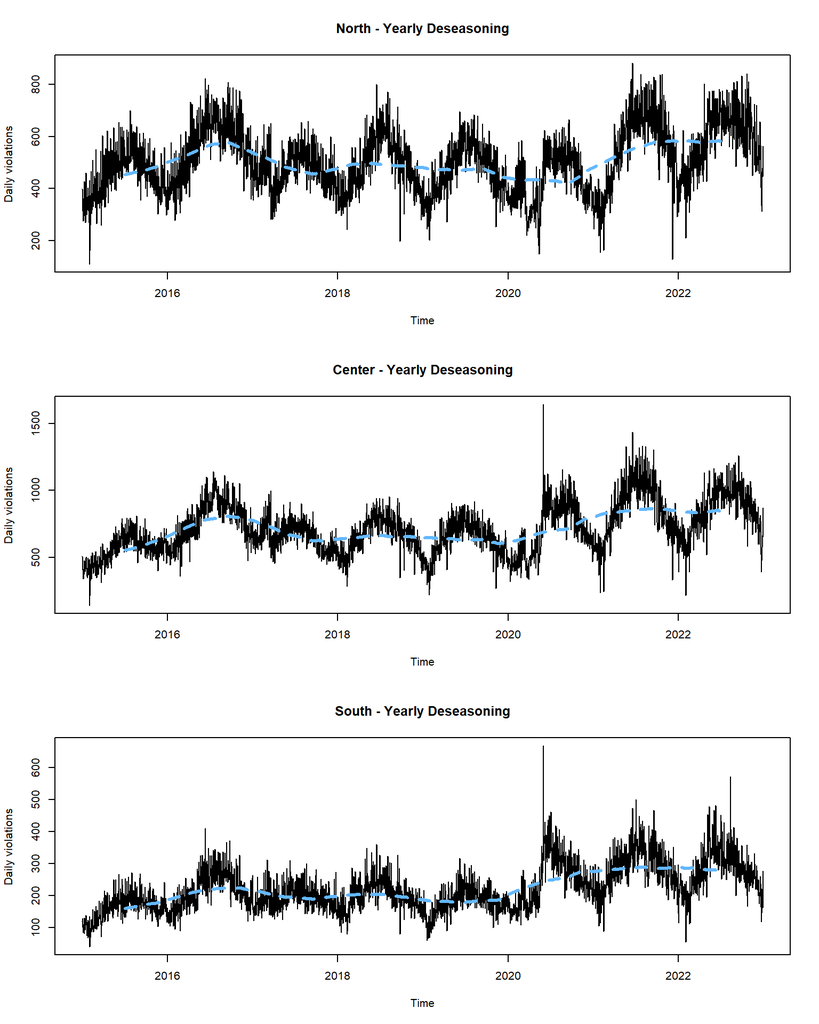

```r
par(mfrow = c(length(area.ts.daily), 1))

for(area_name in names.area) {

  daily <- area.ts.daily[[area_name]]

  plot(
    daily,
    main=paste(area_name, "- Yearly Deseasoning"),
    ylab="Daily violations"
  )

  deseasonal.trend = deseasoning(
    ts=daily,
    as.integer(daily.freq)
  )

  lines(
    deseasonal.trend,
    lty='dashed', lwd=3,
    col='steelblue1'
  )

}
```

```r
par(mfrow=c(1,1))
```

Which by construction we expect to look quite similar to the yearly deseasoning of monthly data.

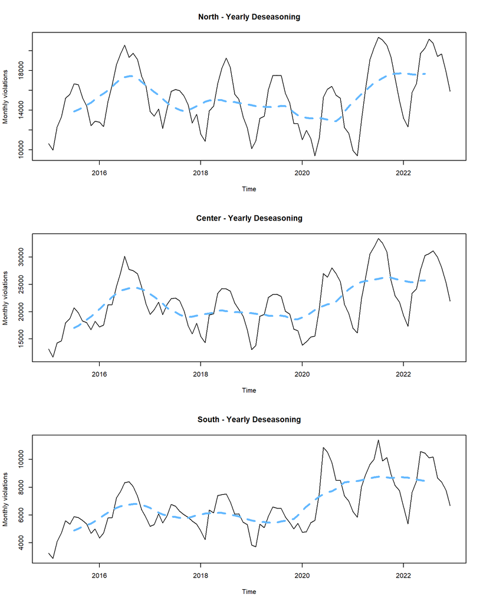

```r
par(mfrow = c(length(area.ts.daily), 1))

for(area_name in names.area) {

  monthly <- area.ts.monthly[[area_name]]

  plot(
    monthly,
    main=paste(area_name, "- Yearly Deseasoning"),
    ylab="Monthly violations"
  )

  deseasonal.trend = deseasoning(
    ts=monthly,
    as.integer(monthly.freq)
  )

  lines(
    deseasonal.trend,
    lty='dashed', lwd=3,
    col='steelblue1'
  )

}
```

```r
par(mfrow=c(1,1))
```

#### Monthplot

monthplots shows evidence of importance of seasonality but also a recurrent trends.

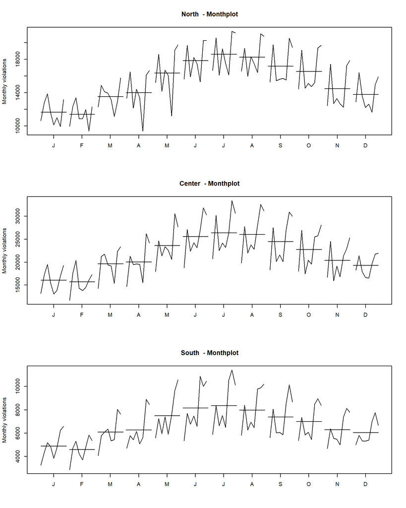

```r
par(mfrow = c(length(area.ts.monthly), 1))

for (area_name in names.area) {

  monthly <- area.ts.monthly[[area_name]]

  monthplot(
    monthly,
    main=paste(area_name, " - Monthplot"),
    ylab="Monthly violations"
  )

}
```

```r
par(mfrow=c(1,1))
```

#### Moving Average Decomposition

We better inspect the role of trend and seasonality by exploiting Moving Average Decomposition.

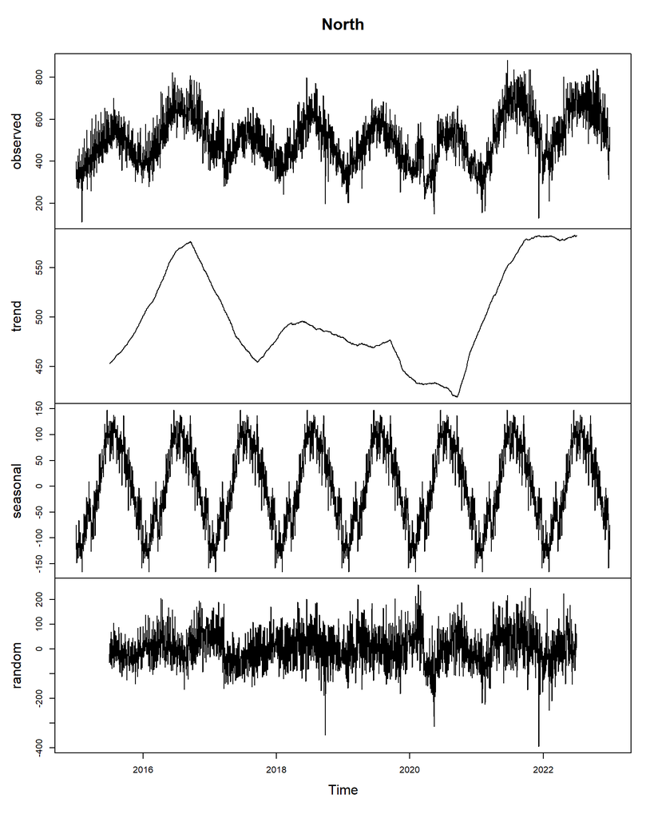

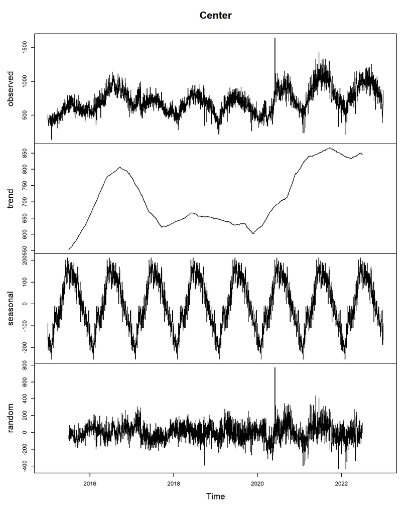

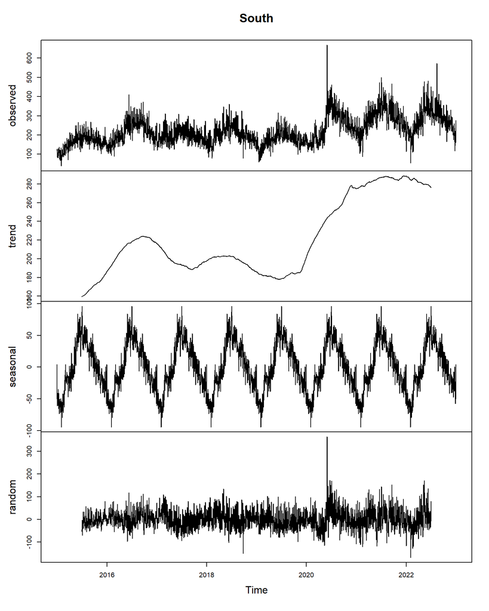

```r
for(area_name in names.area) {

  daily <- area.ts.daily[[area_name]]

  plot_ma_decomposition(
    ts=daily,
    main=area_name
  )
}
```

Similar trend, different behaviour for south, bigger than before. Evidence in north and center errors

Let’s see the trend

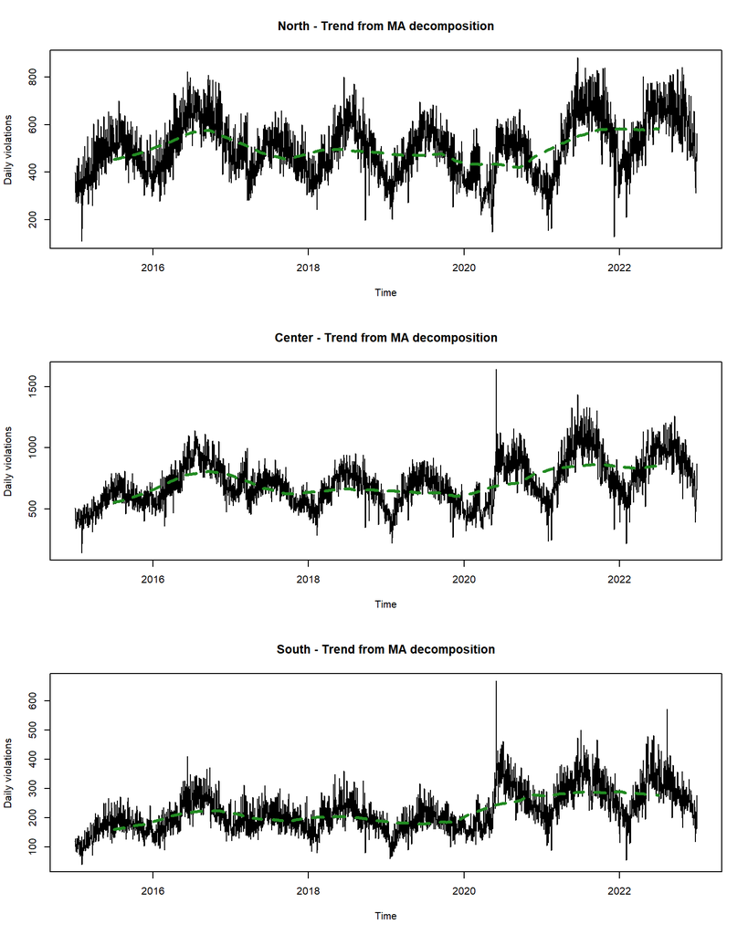

```r
par(mfrow = c(length(area.ts.daily), 1))

for(area_name in names.area) {

  daily <- area.ts.daily[[area_name]]

  plot(
    daily,
    main=paste(area_name, "- Trend from MA decomposition"),
    ylab="Daily violations"
  )

  trend = decompose(daily)$trend

  lines(
    trend,
    lty='dashed', lwd=3,
    col='forestgreen'
  )

}
```

```r
par(mfrow=c(1,1))
```

### STL

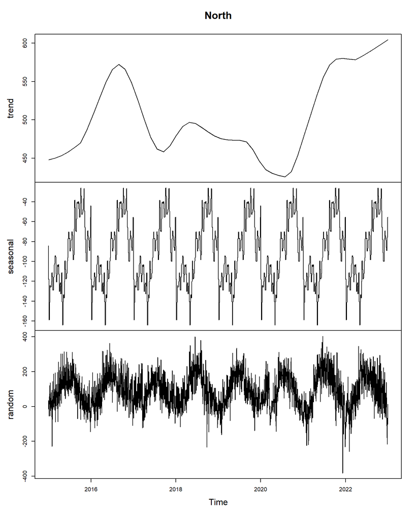

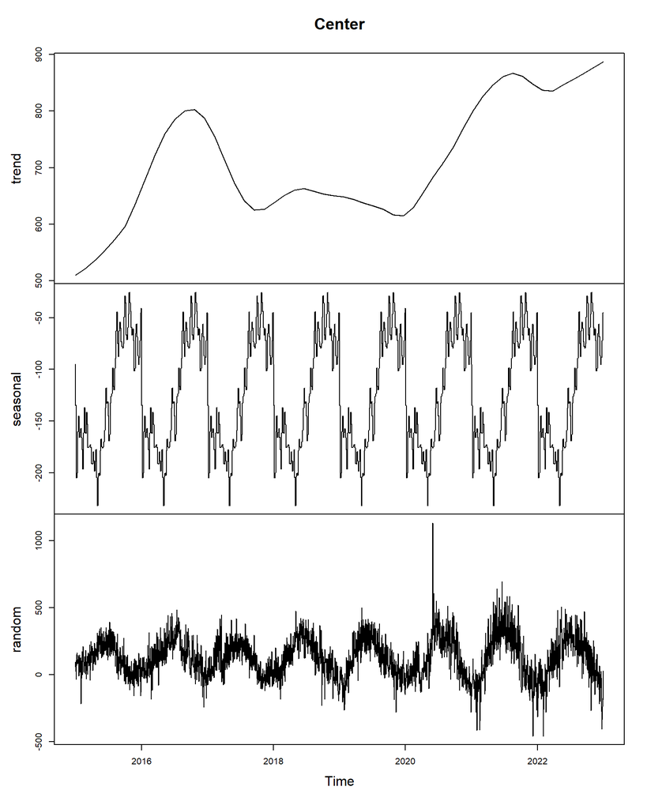

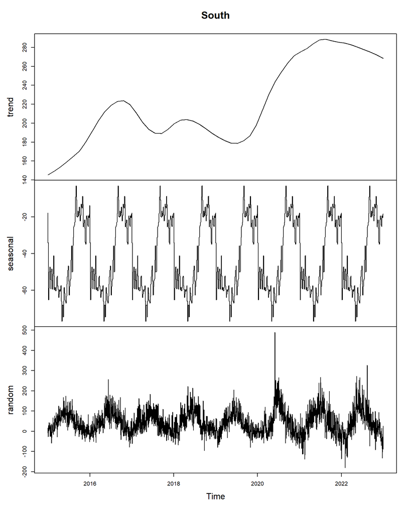

```r
for(area_name in names.area) {

  daily <- area.ts.daily[[area_name]]

  plot_stl_decomposition(
    ts=daily,
    main=area_name
  )
}
```

Let’s compare individual components of the three

Trend

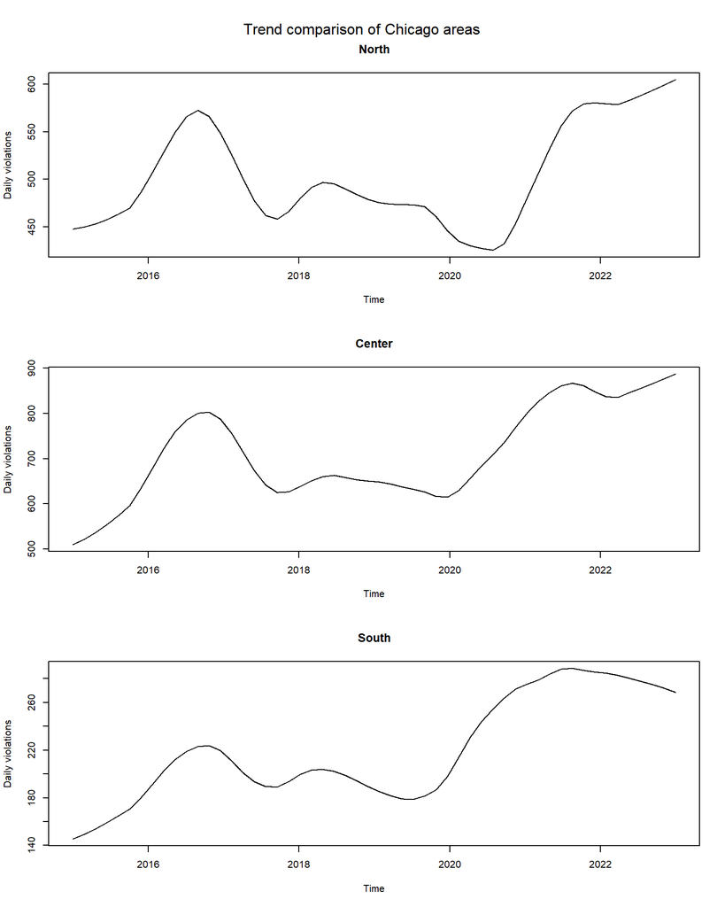

```r
plot_stl_components(
  ts_list = list(
    area.ts.daily$North,
    area.ts.daily$Center,
    area.ts.daily$South
  ),
  names=names.area,
  component_name="trend",
  main=paste("Trend comparison of Chicago areas"),
  ylab="Daily violations"
)
```

Seasonal

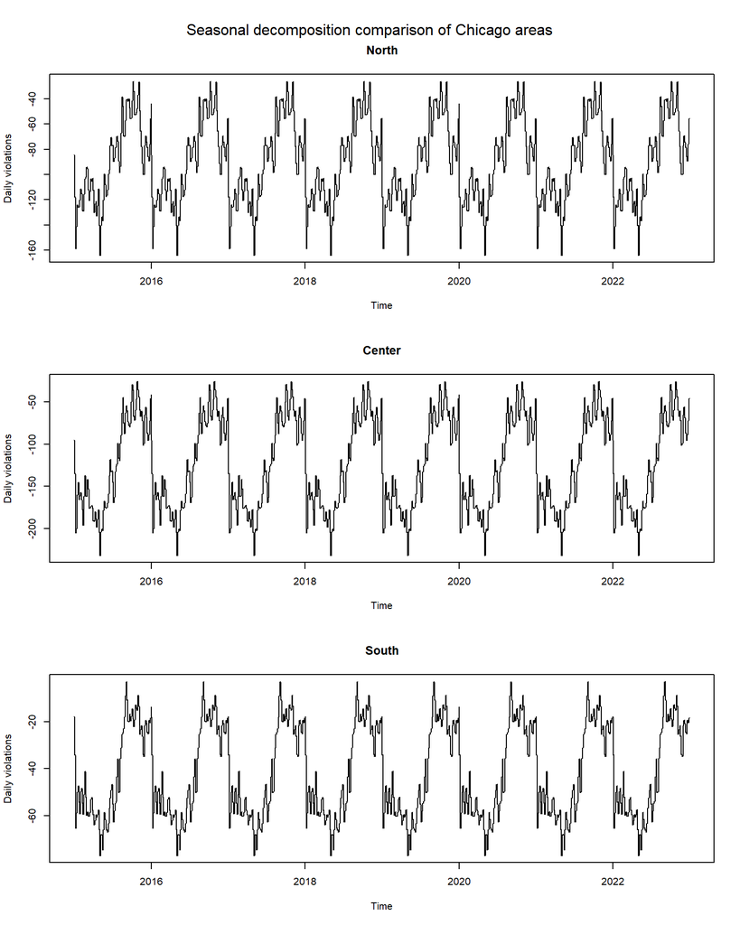

```r
plot_stl_components(
  ts_list = list(
    area.ts.daily$North,
    area.ts.daily$Center,
    area.ts.daily$South
  ),
  names=names.area,
  component_name="seasonal",
  main=paste("Seasonal decomposition comparison of Chicago areas"),
  ylab="Daily violations"
)
```

Error

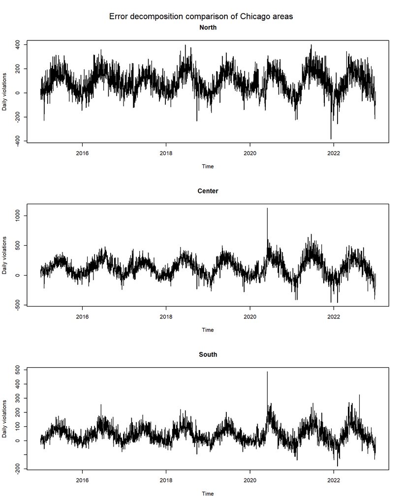

```r
plot_stl_components(
  ts_list = list(
    area.ts.daily$North,
    area.ts.daily$Center,
    area.ts.daily$South
  ),
  names=names.area,
  component_name="remainder",
  main=paste("Error decomposition comparison of Chicago areas"),
  ylab="Daily violations"
)
```

# 2. Analyzing weekly